# Solut

2022-12-21

# Assignment 1

## Part 1

```r
df=read.csv("Rice.csv")

library(caret)
df1=df
scaler=preProcess(df1[,1:7])
df1[,1:7]=predict(scaler, df1[,1:7])

library(glmnet)

covariates=as.matrix(df1[,1:7])
response=df1[, 8]
model=cv.glmnet(covariates, response, alpha=1,family="binomial")
model$lambda.min
```

```
## [1] 5.942255e-05
```

The optimal penalty factor reported above.

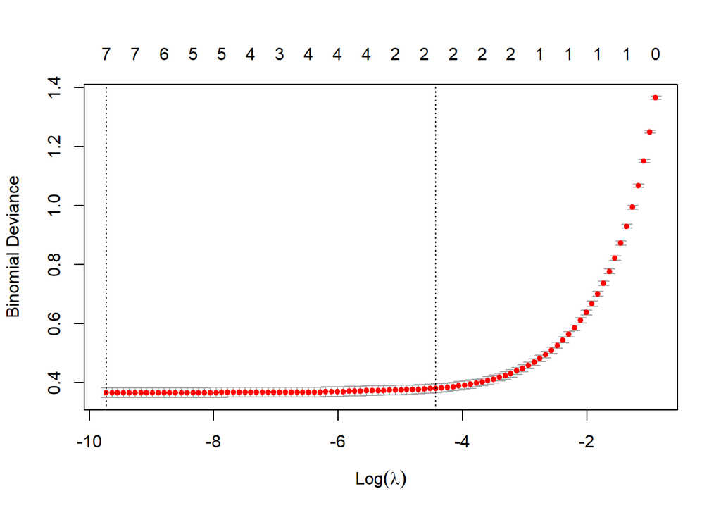

```r
plot(model)
```

The optimal model has 7 features. It can be seen that models having 6 features have overlapping intervals with models having 7 features. It can therefore not be stated that model with 7 features is statistically significantly better.

```r
coef(model, s="lambda.min")
```

```
## 8 x 1 sparse Matrix of class "dgCMatrix"
##                              s1
## (Intercept)        6.534405e-01
## Area               6.145758e+00
## Perimeter          1.587641e+00
## Major_Axis_Length -6.606220e-01
## Minor_Axis_Length  2.313840e+00
## Eccentricity      -7.153431e-01
## Convex_Area       -1.294943e+01
## Extent            -4.692347e-04
```

All features are selected in the optimal model.

```r
ynew=predict(model, newx=covariates, type="response", s=model$lambda.min)

Pred=ifelse(ynew/(1-ynew)>37/3, "Osmancik", "Cammeo")
table(response, Pred)
```

```
##           Pred
## response   Cammeo Osmancik
##   Cammeo     1604       26
##   Osmancik    527     1653
```

It can be observed that the model has a relatively few misclassifications of “Cameo”. This is because classifying Cameo to Osmancik causes much larger cost according to our loss matrix.

## Part 2

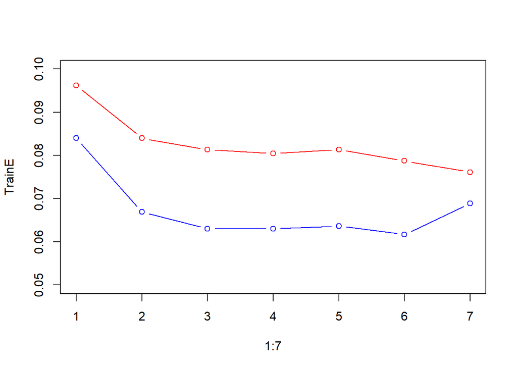

```r
matr=df1[,1:7]

library(MASS)
res=prcomp(matr)

data=as.data.frame(res$x)
data$Class=as.factor(df1$Class)

n=dim(data)[1]
set.seed(12345)
id=sample(1:n, floor(n*0.4))
train=data[id,]
id1=setdiff(1:n, id)
set.seed(12345)
id2=sample(id1, floor(n*0.3))
valid=data[id2,]
id3=setdiff(id1,id2)
test=data[id3,]

missclass=function(X,X1){
  n=length(X)
  return(1-sum(diag(table(X,X1)))/n)
}

TrainE=numeric(7)
ValidE=numeric(7)

for (i in 1:7){
  train1=train[, c(1:i, 8)]
  valid1=valid[, c(1:i, 8)]
  m=glm(Class~., data=train1, family="binomial")
  Ptr=ifelse(predict(m, newdata=train1, type="response")>0.5, "Osmancik", "Cammeo")
  Pvalid=ifelse(predict(m, newdata=valid1, type="response")>0.5, "Osmancik", "Cammeo")

  TrainE[i]=missclass(train1$Class, Ptr)
  ValidE[i]=missclass(valid1$Class, Pvalid)

}
plot(1:7, TrainE, type="b", col="blue", ylim=c(0.05,0.1))
points(1:7, ValidE, type="b", col="red")
```

The training error of the model goes down (but not monotonically since a different sort of error function is optimized) which corresponds to descreased bias, but the variance increases.The validation error is a balance between bias and variance terms, and the best model corresponds to he lowest validation error. The optimal model is using all features and the validation error still has a downgoing trend which means that it can be advantageous to decrease bias even more (if some additional variables are added).

```r
which.min(ValidE)
```

```
## [1] 7
```

The optimal model has all 7 features.

```r
m=glm(Class~., data=train, family="binomial")
Ptest=ifelse(predict(m, newdata=test, type="response")>0.5, "Osmancik", "Cammeo")
TestE=missclass(test$Class, Ptest)

print(c(TrainE[7], ValidE[7], TestE))
```

```
## [1] 0.06889764 0.07611549 0.06911636
```

Test error has a comparable magnitude to training and validation errors which means that the model can reliably predict new data with the stated accuracy and is not overfit to training and validation sets.

## Part 3

```r
res$rotation[,1:2]
```

```
##                           PC1         PC2
## Area              -0.46125179 -0.12437713
## Perimeter         -0.46440793  0.05575087
## Major_Axis_Length -0.44707633  0.21345616
## Minor_Axis_Length -0.32175200 -0.56710548
## Eccentricity      -0.22732878  0.67315219
## Convex_Area       -0.46169356 -0.12253499
## Extent             0.05771599 -0.38223203
```

```r
scaler$mean[1]
```

```
##     Area
## 12667.73
```

```r
scaler$std[1]
```

```
##     Area
## 1732.368
```

Scaled data equation $Area=-0.461PC1-0.124PC2$

Original data equation: $Area=1732.368*(-0.461PC1-0.124PC2)+12667.73=-798.622PC1-214.814PC2+12667.73$